# Inferential Statistics Project: what will your baby’s weight be?

Mattia Guglielmelli

2023-03-31

Let us start by importing the dataset and the libraries we are going to use:

```r
library(moments)
library(dplyr)
library(ggplot2)
library(ggpubr)
library(GGally)
library(car)
library(lmtest)
library(scatterplot3d)

data <- read.csv("newborns.csv", stringsAsFactors = T)
data$Smoker <- as.factor(data$Smoker)
head(data,10)
```

```
##    Mother.age Pregnancies.number Smoker Gestation.weeks Weight Length Cranium
## 1          26                  0      0              42   3380    490     325
## 2          21                  2      0              39   3150    490     345
## 3          34                  3      0              38   3640    500     375
## 4          28                  1      0              41   3690    515     365
## 5          20                  0      0              38   3700    480     335
## 6          32                  0      0              40   3200    495     340
## 7          26                  1      0              39   3100    480     345
## 8          25                  0      0              40   3580    510     349
## 9          22                  1      0              40   3670    500     335
## 10         23                  0      0              41   3700    510     362
##    Birth.type Hospital Sex
## 1         Nat    hosp3   M
## 2         Nat    hosp1   F
## 3         Nat    hosp2   M
## 4         Nat    hosp2   M
## 5         Nat    hosp3   F
## 6         Nat    hosp2   F
## 7         Nat    hosp3   F
## 8         Nat    hosp1   M
## 9         Ces    hosp2   F
## 10        Ces    hosp2   F
```

It contains data on 2500 newborns collected from 3 different hospitals. There are 10 variables for each observable:

- `Mother.age`: the mother’s age (continuous quantitative variable);
- `Pregnancies.number`: the number of pregnancies the mother has already gone through (discrete quantitative variable);
- `Smoker`: it is 0 if the mother does not smoke, otherwise it is 1 (qualitative nominal variable);
- `Gestation.weeks`: number of gestation’s weeks (continuous quantitative variable);
- `Weight`: baby’s weight, in g (continuous quantitative variable);
- `Length`: baby’s length, in mm (continuous quantitative variable);
- `Cranium`: diameter of the baby’s cranium, in mm (continuous quantitative variable);
- `Birth.type`: birth type, Natural or Cesarean (qualitative nominal variable);
- `Hospital`: hospital, 1, 2 or 3 (qualitative nominal variable);
- `Sex`: baby’s sex, Male or Female (qualitative nominal variable).

The project aims at predicting the baby’s weight, given all the other variables. Therefore, we will study how the variables influence the weight and see which of them play a relevant role in its determination. To achieve this objective, we use **multiple linear regression**.

First of all, let us quickly summarize every column in the dataset by means of the `summary()` function:

```r
summary(data)
```

```
##    Mother.age    Pregnancies.number Smoker   Gestation.weeks     Weight
##  Min.   : 0.00   Min.   : 0.0000    0:2396   Min.   :25.00   Min.   : 830
##  1st Qu.:25.00   1st Qu.: 0.0000    1: 104   1st Qu.:38.00   1st Qu.:2990
##  Median :28.00   Median : 1.0000             Median :39.00   Median :3300
##  Mean   :28.16   Mean   : 0.9812             Mean   :38.98   Mean   :3284
##  3rd Qu.:32.00   3rd Qu.: 1.0000             3rd Qu.:40.00   3rd Qu.:3620
##  Max.   :46.00   Max.   :12.0000             Max.   :43.00   Max.   :4930
##      Length         Cranium    Birth.type  Hospital   Sex
##  Min.   :310.0   Min.   :235   Ces: 728   hosp1:816   F:1256
##  1st Qu.:480.0   1st Qu.:330   Nat:1772   hosp2:849   M:1244
##  Median :500.0   Median :340              hosp3:835
##  Mean   :494.7   Mean   :340
##  3rd Qu.:510.0   3rd Qu.:350
##  Max.   :565.0   Max.   :390
```

We see that the minimum value of the variable `Mother.age` is 0, so let us check:

```r
filter(data,Mother.age<10)
```

```
##   Mother.age Pregnancies.number Smoker Gestation.weeks Weight Length Cranium
## 1          1                  1      0              41   3250    490     350
## 2          0                  0      0              39   3060    490     330
##   Birth.type Hospital Sex
## 1        Nat    hosp2   F
## 2        Nat    hosp3   M
```

These values are impossible for a mother’s age. However, the rest of the information contained in the rows with `Mother.age` equal to 0 or 1 seems plausible. Therefore, we choose to keep them, by modifying the value of `Mother.age`. To do this, we perform the **Kolmogorov-Smirnov test** between the sample obtained by removing the abnormal values and the sample where the latter are replaced either by the mean or the median of the sample:

```r
col_clean <- subset(data,Mother.age>2)$Mother.age
ks_mean <- dgof::ks.test(col_clean,replace(data$Mother.age,
                                           data$Mother.age<2,
                                           mean(col_clean)))
ks_median <- dgof::ks.test(col_clean,replace(data$Mother.age,
                                             data$Mother.age<2,
                                             median(col_clean)))
ks_median$statistic;ks_mean$statistic
```

```
##            D
## 0.0003746998
```

```
##            D
## 0.0004253002
```

We see that the lowest value of the Kolmogorov-Smirnov statistic is achieved by means of the median. In general, we could consider all the values taken by the `Mother.age` variable and see what is the one that minimizes the Kolmogorov-Smirnov statistic:

```r
values <- sort(unique(subset(data,Mother.age>2)$Mother.age))
dists <- c()

for (x in values) {
    col_filled <- replace(data$Mother.age,data$Mother.age<2,x)
    ks <- dgof::ks.test(col_clean,col_filled)
    dists <- c(dists,ks$statistic)
}

values[match(min(dists),dists)]
```

```
## [1] 28
```

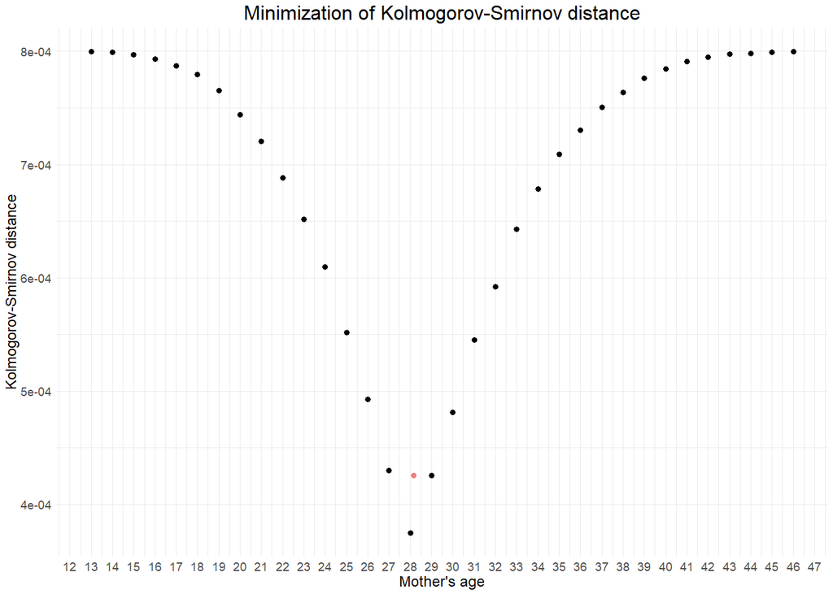

```r
ggplot()+
    geom_point(aes(x=values,
                   y=dists),
               colour = "black",
               size = 3)+
    geom_point(aes(x=mean(data$Mother.age),
                   y=ks_mean$statistic),
               colour = "lightcoral",
               size = 3)+
    scale_x_continuous(breaks=seq(10,50))+
    labs(title = "Minimization of Kolmogorov-Smirnov distance",
         x = "Mother's age",
         y = "Kolmogorov-Smirnov distance")+
    theme_minimal()+
    theme(plot.title = element_text(size = 24, hjust = 0.5),
          axis.text.x = element_text(size = 14),
          axis.text.y = element_text(size = 14),
          axis.title = element_text(size = 18))
```

We are led to choose the median even with this more general approach. Therefore, we choose to replace the abnormal values of `Mother.age` with the median, namely 28:

```r
data$Mother.age <- replace(data$Mother.age,data$Mother.age<2,median(col_clean))
```

Let us test if the average baby’s weight and length are comparable with the averages of the population. Before doing it, let us see if the sex of the newborn is statistically significant as far as the weight and length are concerned. To this aim, we perform a **two-sample t-test**:

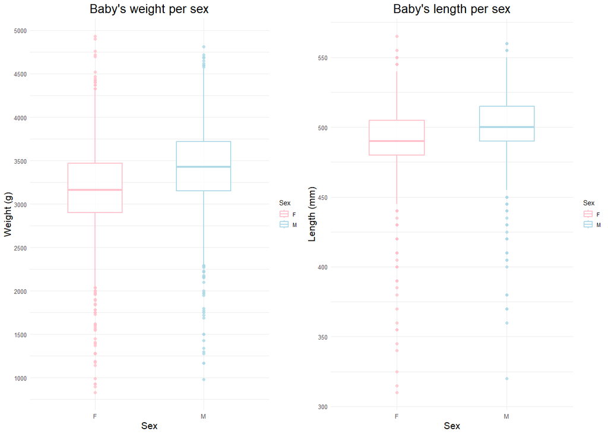

```r
my2cols <- c("pink","lightblue")
p_weight <- ggplot(data, aes(x=Sex,y=Weight))+
                geom_boxplot(aes(color = Sex),
                             alpha=0.8,
                             width = 0.5,
                             outlier.shape=16,
                             outlier.size=2,
                             linewidth = 0.75,
                             outlier.stroke = 0.75
                             )+
                scale_color_manual(values = my2cols)+
                scale_y_continuous(breaks = seq(500,5500,500))+
                labs(x="Sex",
                     y="Weight (g)",
                     title = "Baby's weight per sex")+
                theme_minimal()+
                theme(plot.title = element_text(size = 20, hjust = 0.5),
                    axis.text.x = element_text(size = 10),
                    axis.text.y = element_text(size = 10),
                    axis.title = element_text(size = 16))

p_length <- ggplot(data, aes(x=Sex,y=Length))+
                geom_boxplot(aes(color = Sex),
                             alpha=0.8,
                             width = 0.5,
                             outlier.shape=16,
                             outlier.size=2,
                             linewidth = 0.75,
                             outlier.stroke = 0.75
                             )+
                scale_color_manual(values = my2cols)+
                scale_y_continuous(breaks = seq(300,600,50))+
                labs(x="Sex",
                     y="Length (mm)",
                     title = "Baby's length per sex")+
                theme_minimal()+
                theme(plot.title = element_text(size = 20, hjust = 0.5),
                    axis.text.x = element_text(size = 10),
                    axis.text.y = element_text(size = 10),
                    axis.title = element_text(size = 16))

ggarrange(p_weight,p_length,nrow = 1)
```

```r
t_weight <-t.test(data = data,
                  Weight ~ Sex,
                  paired = F)
t_length <-t.test(data = data,
                  Length ~ Sex,
                  paired = F)
t_weight$p.value;t_length$p.value
```

```
## [1] 8.029743e-33
```

```
## [1] 2.237243e-21
```

In both cases, the p-value is very small, therefore we reject the null hypothesis, concluding that the difference between the 2 mean values is statistically significant.

According to [this site](https://www.babycenter.com/baby/baby-development/average-weight-and-growth-chart-for-babies-toddlers-and-beyo_10357633), in the United States, the average baby’s weight at birth is 3.2 kg for girls and 3.4 kg for boys, while the average newborn is 49.5 cm long, with girls measuring 49.2 cm and boys measuring 49.9 cm.  
Let us now see if the difference between the averages of the sample and those of the population are statistically significant, by performing 4 different t-tests:

```r
t_weight_F <- t.test(filter(data, Sex=="F")["Weight"],
                     mu = 3200,
                     conf.level = 0.95,
                     alternative = "two.sided")

t_weight_M <- t.test(filter(data, Sex=="M")["Weight"],
                     mu = 3400,
                     conf.level = 0.95,
                     alternative = "two.sided")

t_length_F <- t.test(filter(data, Sex=="F")["Length"],
                     mu = 492,
                     conf.level = 0.95,
                     alternative = "two.sided")

t_length_M <- t.test(filter(data, Sex=="M")["Length"],
                     mu = 499,
                     conf.level = 0.95,
                     alternative = "two.sided")

t_weight_F$p.value;t_weight_M$p.value;t_length_F$p.value;t_length_M$p.value
```

```
## [1] 0.008970849
```

```
## [1] 0.5574484
```

```
## [1] 0.004074962
```

```
## [1] 0.3277868
```

The values found on internet about the averages of the population are not the same for every site, and small changes in the average weight and length of girls lead to a much higher p-value. For example, if we consider an average of 3150 g and 491 mm for the girls’ weight and length, respectively, we will find:

```r
t_weight_F_3150 <- t.test(filter(data, Sex=="F")["Weight"],
                     mu = 3150,
                     conf.level = 0.95,
                     alternative = "two.sided")
t_length_F <- t.test(filter(data, Sex=="F")["Length"],
                     mu = 491,
                     conf.level = 0.95,
                     alternative = "two.sided")
t_weight_F_3150$p.value;t_length_F$p.value
```

```
## [1] 0.453632
```

```
## [1] 0.1119809
```

that are bigger than the significance level of 5%. Therefore, we conclude that the ignorance of the precise value of the average weight and length of the population do not allow to draw conclusions with any certainty. Nevertheless, we can say that the sample shows the same trend as the population, as far as the dependence of weight and length on sex is concerned.

We can also study if the sex influences the number of gestation weeks and the diameter of cranium:

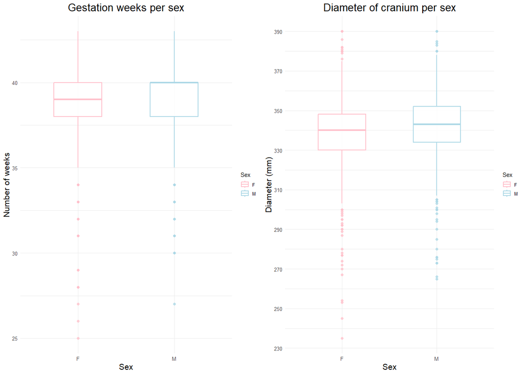

```r
my2cols <- c("pink","lightblue")
p_weight <- ggplot(data, aes(x=Sex,y=Gestation.weeks))+
                geom_boxplot(aes(color = Sex),
                             alpha=0.8,
                             width = 0.5,
                             outlier.shape=16,
                             outlier.size=2,
                             linewidth = 0.75,
                             outlier.stroke = 0.75
                             )+
                scale_color_manual(values = my2cols)+
                scale_y_continuous(breaks = seq(25,45,5))+
                labs(x="Sex",
                     y="Number of weeks",
                     title = "Gestation weeks per sex")+
                theme_minimal()+
                theme(plot.title = element_text(size = 20, hjust = 0.5),
                    axis.text.x = element_text(size = 10),
                    axis.text.y = element_text(size = 10),
                    axis.title = element_text(size = 16))

p_length <- ggplot(data, aes(x=Sex,y=Cranium))+
                geom_boxplot(aes(color = Sex),
                             alpha=0.8,
                             width = 0.5,
                             outlier.shape=16,
                             outlier.size=2,
                             linewidth = 0.75,
                             outlier.stroke = 0.75
                             )+
                scale_color_manual(values = my2cols)+
                scale_y_continuous(breaks=seq(230,410,20))+
                labs(x="Sex",
                     y="Diameter (mm)",
                     title = "Diameter of cranium per sex")+
                theme_minimal()+
                theme(plot.title = element_text(size = 20, hjust = 0.5),
                    axis.text.x = element_text(size = 10),
                    axis.text.y = element_text(size = 10),
                    axis.title = element_text(size = 16))

ggarrange(p_weight,p_length,nrow = 1)
```

```r
t.test(data = data,
       Gestation.weeks ~ Sex,
       paired = F)
```

```
##
##  Welch Two Sample t-test
##
## data:  Gestation.weeks by Sex
## t = -6.7072, df = 2446.6, p-value = 2.456e-11
## alternative hypothesis: true difference in means between group F and group M is not equal to 0
## 95 percent confidence interval:
##  -0.6418172 -0.3514294
## sample estimates:
## mean in group F mean in group M
##        38.73328        39.22990
```

```r
t.test(data = data,
       Cranium ~ Sex,
       paired = F)
```

```
##
##  Welch Two Sample t-test
##
## data:  Cranium by Sex
## t = -7.4102, df = 2491.4, p-value = 1.718e-13
## alternative hypothesis: true difference in means between group F and group M is not equal to 0
## 95 percent confidence interval:
##  -6.089912 -3.541270
## sample estimates:
## mean in group F mean in group M
##        337.6330        342.4486
```

Both p-values are very small, therefore we conclude that the difference between the mean values of the number of gestation weeks, computed for each sex, is statistically significant. The same holds for the diameter of the cranium.

We can also study if there is some correlation between the birth type and the newborn’s sex. In this respect, since both are categorical variables, let us look at the contingency table:

```r
contingency_birth_sex <- table(data$Birth.type,data$Sex)
contingency_birth_sex
```

```
##
##         F   M
##   Ces 363 365
##   Nat 893 879
```

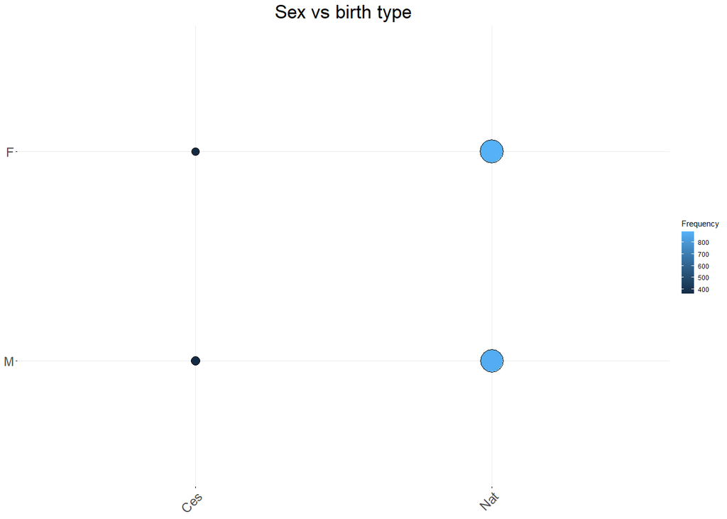

```r
ggballoonplot(data = as.data.frame(contingency_birth_sex),
              fill = "value",
              size.range = c(5,15))+
    scale_fill_gradient()+
    guides(size = F)+
    labs(x="Birth type",
         y="Sex",
         title = "Sex vs birth type",
         fill="Frequency")+
    theme(plot.title = element_text(size = 26, hjust = 0.5),
          axis.text.x = element_text(size = 18),
          axis.text.y = element_text(size = 18),
          axis.title = element_text(size = 20))
```

From the plot, we see that there is no correlation between the two variables. This is confirmed by the **Chi-Square test of independence**:

```r
chisq.test(contingency_birth_sex)
```

```
##
##  Pearson's Chi-squared test with Yates' continuity correction
##
## data:  contingency_birth_sex
## X-squared = 0.039147, df = 1, p-value = 0.8432
```

Indeed, since the p-value is higher than 0.05, we do not reject the null hypothesis of independence of the two categorical variables.

The last analysis we are going to perform is that regarding the correlation between the birth type and the hospital. To this aim, we again build the contingency table and carry out the Chi-Square test of independece:

```r
contingency_birth_hospital <- table(data$Birth.type,data$Hospital)
contingency_birth_hospital
```

```
##
##       hosp1 hosp2 hosp3
##   Ces   242   254   232
##   Nat   574   595   603
```

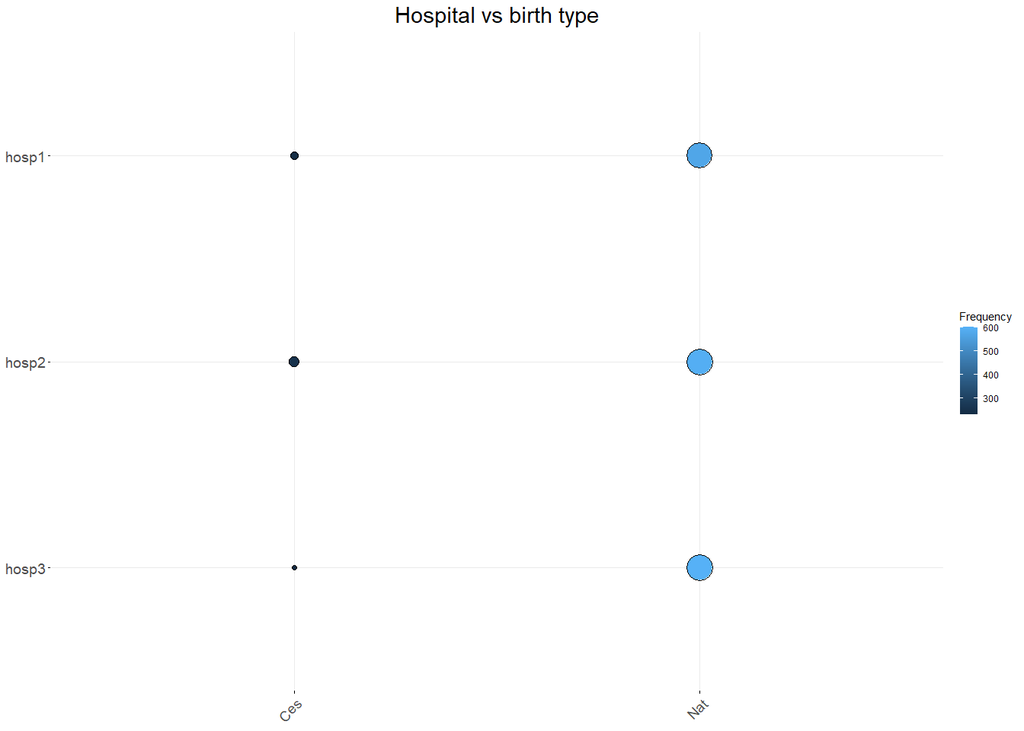

```r
ggballoonplot(data = as.data.frame(contingency_birth_hospital),
              fill = "value",
              size.range = c(2,12))+
    scale_fill_gradient()+
    labs(x="Birth type",
         y="Hospital",
         title = "Hospital vs birth type",
         fill = "Frequency")+
    guides(size=F)+
    theme(plot.title = element_text(size = 22, hjust = 0.5),
          axis.text.x = element_text(size = 14),
          axis.text.y = element_text(size = 14),
          axis.title = element_text(size = 16),
          legend.title.align = 0.5)
```

```r
chisq.test(contingency_birth_hospital)
```

```
##
##  Pearson's Chi-squared test
##
## data:  contingency_birth_hospital
## X-squared = 1.0972, df = 2, p-value = 0.5778
```

The p-value is about 0.58, therefore we do not reject the null hypothesis and conclude that the correlation between the two variables is not statistically significant.

Before starting with the feature selection procedure, let us build a plot matrix, consisting of plots to properly visualize the correlation of each variable combination of the dataframe:

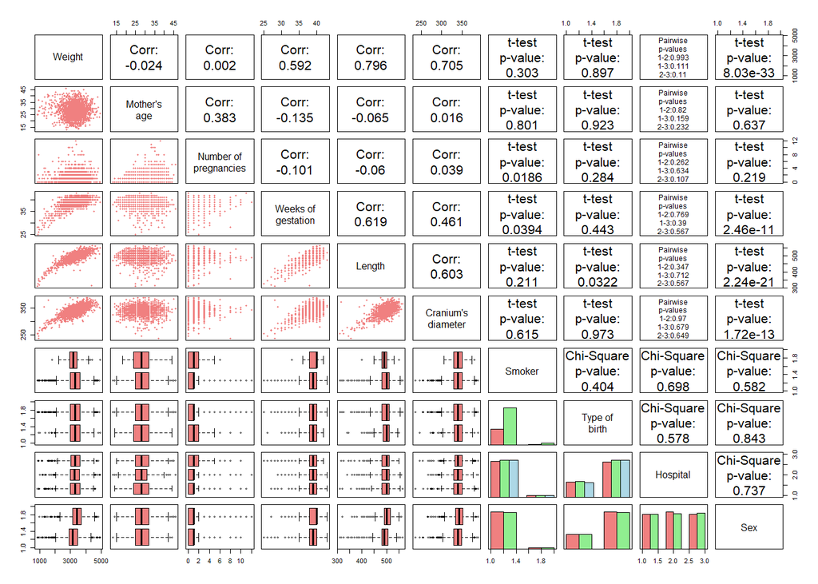

```r
data <- data %>%
    relocate(Weight,.before = Mother.age) %>%
    relocate(Smoker,.before = Birth.type)

panel.corr <- function(x, y){

    par(usr = c(0, 1, 0, 1))

    if (length(unique(x))<=3 & length(unique(y))<=3){

        contingency_table <- table(y,x)
        test <- chisq.test(contingency_table)
        p.value <- test$p.value
        txt <- paste("Chi-Square","p-value:", signif(p.value,3), sep="\n")
        text(0.5, 0.5, txt, cex = 2)
    }
    else if (length(unique(x))==3 & length(unique(y))>3) {


        test <- pairwise.t.test(y,
                    x,
                    paired = F,
                    pool.sd = T,
                    p.adjust.method = "none")
        osp_12 <- test$p.value[1,1]
        osp_13 <- test$p.value[2,1]
        osp_23 <- test$p.value[2,2]
        txt <- paste("Pairwise\n",
                     "p-values\n",
                     "1-2:", signif(osp_12,3), "\n",
                     "1-3:", signif(osp_13,3), "\n",
                     "2-3:", signif(osp_23,3), sep="")
        text(0.5, 0.5, txt, cex = 1.1)

    }
    else if (length(unique(x))==2 & length(unique(y))>3) {

        test <- t.test(y ~ x,
           paired = F)
        p.value <- test$p.value
        txt <- paste("t-test",
                     "p-value:",
                     signif(p.value,3),
                     sep="\n")
        text(0.5, 0.5, txt, cex = 2)
    }
    else{

        r <- round(cor(x, y), digits=3)
        txt <- paste("Corr:", r, sep="\n")
        text(0.5, 0.5, txt, cex = 2)

    }
}

panel.scat <- function(x, y){
    if (length(unique(x))>3 & length(unique(y)) %in% c(2,3)){
        par(new=T)
        boxplot(x~y,
                horizontal = T,
                xaxt="n",
                yaxt="n",
                col = "lightcoral")
    }
    else if (length(unique(x))>3 & length(unique(y))>3) {
        points(x,y, pch = 20, cex = 1, col = "lightcoral")
    }
    else{
        if (length(unique(y))==3) {
            par(new=T)
            barplot(table(y,x)/max(table(y,x)),
                    col=c("lightcoral","lightgreen","lightblue"),
                    ylim=c(0,1.2),
                    beside = T,
                    axes=F,
                    xaxt="n")
        }
        else{
            par(new=T)
            barplot(table(y,x)/max(table(y,x)),
                    col=c("lightcoral","lightgreen"),
                    ylim=c(0,1.2),
                    beside = T,
                    axes=F,
                    xaxt="n")
        }
    }
}

big <- function(labels){
    text(mean(x),mean(y),"ciao")
}

pairs(data,
      upper.panel = panel.corr,
      lower.panel = panel.scat,
      cex.labels = 1.5,
      labels = c("Weight", "Mother's\nage","Number of\npregnancies",
                 "Weeks of\ngestation","Length","Cranium's\ndiameter",
                 "Smoker","Type of\nbirth","Hospital","Sex"))
```

We choose to show:

- the linear correlation coefficient when both variables are continuous;
- the p-value of the two-sample t-test when one variable is continuous and the other is dichotomous;
- the p-values of the pairwise t-test when one variable is continuous and the other is categorical with more than 2 levels;
- the p-value of the Chi-Square test of independence when both variables are categorical.

From the values in the first row, we find that the `Weight` variable is highly correlated with the variables `Gestation.weeks`, `Length` and `Cranium`. On the other hand, by looking at the p-values of the same row, it turns out that the newborn’s weight is also highly influenced by the sex (as already seen previously), while it is not significantly dependent on the variables `Smoker`, `Birth.type` and `Hospital`.

Since we would like to make a prediction on a newborn’s weight, let us find a model that well describes how we can deduce it from the other variables. In this respect, let us start from the model containing all the variables:

```r
mod1 <- lm(Weight ~ .,data = data)
summary(mod1)
```

```
##
## Call:
## lm(formula = Weight ~ ., data = data)
##
## Residuals:
##     Min      1Q  Median      3Q     Max
## -1123.3  -181.2   -14.6   160.7  2612.6
##
## Coefficients:
##                      Estimate Std. Error t value Pr(>|t|)
## (Intercept)        -6735.1677   141.3977 -47.633  < 2e-16 ***
## Mother.age             0.7983     1.1463   0.696   0.4862
## Pregnancies.number    11.4118     4.6665   2.445   0.0145 *
## Gestation.weeks       32.5265     3.8179   8.520  < 2e-16 ***
## Length                10.2951     0.3007  34.237  < 2e-16 ***
## Cranium               10.4725     0.4261  24.580  < 2e-16 ***
## Smoker1              -30.1567    27.5396  -1.095   0.2736
## Birth.typeNat         29.5027    12.0848   2.441   0.0147 *
## Hospitalhosp2        -11.2216    13.4388  -0.835   0.4038
## Hospitalhosp3         28.0984    13.4972   2.082   0.0375 *
## SexM                  77.5473    11.1779   6.938 5.07e-12 ***
## ---
## Signif. codes:  0 '***' 0.001 '**' 0.01 '*' 0.05 '.' 0.1 ' ' 1
##
## Residual standard error: 273.9 on 2489 degrees of freedom
## Multiple R-squared:  0.7289, Adjusted R-squared:  0.7278
## F-statistic: 669.1 on 10 and 2489 DF,  p-value: < 2.2e-16
```

The variable with the corresponding coefficient having the highest p-value is `Mother.age`, therefore we eliminate it from the model:

```r
mod2 <- update(mod1,~.-Mother.age)
summary(mod2)
```

```
##
## Call:
## lm(formula = Weight ~ Pregnancies.number + Gestation.weeks +
##     Length + Cranium + Smoker + Birth.type + Hospital + Sex,
##     data = data)
##
## Residuals:
##      Min       1Q   Median       3Q      Max
## -1113.93  -180.11   -16.36   160.58  2616.96
##
## Coefficients:
##                      Estimate Std. Error t value Pr(>|t|)
## (Intercept)        -6708.1065   135.9394 -49.346  < 2e-16 ***
## Pregnancies.number    12.6085     4.3381   2.906  0.00369 **
## Gestation.weeks       32.2501     3.7968   8.494  < 2e-16 ***
## Length                10.2944     0.3007  34.239  < 2e-16 ***
## Cranium               10.4876     0.4255  24.651  < 2e-16 ***
## Smoker1              -30.3092    27.5359  -1.101  0.27113
## Birth.typeNat         29.5351    12.0834   2.444  0.01458 *
## Hospitalhosp2        -11.0816    13.4359  -0.825  0.40957
## Hospitalhosp3         28.3660    13.4903   2.103  0.03559 *
## SexM                  77.6205    11.1763   6.945 4.81e-12 ***
## ---
## Signif. codes:  0 '***' 0.001 '**' 0.01 '*' 0.05 '.' 0.1 ' ' 1
##
## Residual standard error: 273.9 on 2490 degrees of freedom
## Multiple R-squared:  0.7288, Adjusted R-squared:  0.7278
## F-statistic: 743.6 on 9 and 2490 DF,  p-value: < 2.2e-16
```

The adjusted $R^2$ is basically the same as before, and this provides additional evidence that `Mother.age` can be dropped from the model. Let us proceed with the feature selection by removing the `Hospital` variable:

```r
mod3 <- update(mod2,~.-Hospital)
summary(mod3)
```

```
##
## Call:
## lm(formula = Weight ~ Pregnancies.number + Gestation.weeks +
##     Length + Cranium + Smoker + Birth.type + Sex, data = data)
##
## Residuals:
##      Min       1Q   Median       3Q      Max
## -1130.04  -181.29   -16.31   160.59  2635.32
##
## Coefficients:
##                     Estimate Std. Error t value Pr(>|t|)
## (Intercept)        -6708.074    135.984 -49.330  < 2e-16 ***
## Pregnancies.number    13.012      4.342   2.997  0.00276 **
## Gestation.weeks       32.541      3.801   8.561  < 2e-16 ***
## Length                10.272      0.301  34.129  < 2e-16 ***
## Cranium               10.501      0.426  24.648  < 2e-16 ***
## Smoker1              -31.759     27.570  -1.152  0.24946
## Birth.typeNat         30.296     12.098   2.504  0.01234 *
## SexM                  78.114     11.191   6.980 3.77e-12 ***
## ---
## Signif. codes:  0 '***' 0.001 '**' 0.01 '*' 0.05 '.' 0.1 ' ' 1
##
## Residual standard error: 274.3 on 2492 degrees of freedom
## Multiple R-squared:  0.7278, Adjusted R-squared:  0.7271
## F-statistic:   952 on 7 and 2492 DF,  p-value: < 2.2e-16
```

Even in this case, the tiny decrease in the adjusted $R^2$ tells us that `Hospital` provides no real improvement in the model. At this point, let us also drop the `Smoker` variable and see what happens:

```r
mod4 <- update(mod3,~.-Smoker)
summary(mod4)
```

```
##
## Call:
## lm(formula = Weight ~ Pregnancies.number + Gestation.weeks +
##     Length + Cranium + Birth.type + Sex, data = data)
##
## Residuals:
##      Min       1Q   Median       3Q      Max
## -1129.31  -181.70   -16.31   161.07  2638.85
##
## Coefficients:
##                      Estimate Std. Error t value Pr(>|t|)
## (Intercept)        -6707.2971   135.9911 -49.322  < 2e-16 ***
## Pregnancies.number    12.7558     4.3366   2.941   0.0033 **
## Gestation.weeks       32.2713     3.7941   8.506  < 2e-16 ***
## Length                10.2864     0.3007  34.207  < 2e-16 ***
## Cranium               10.5057     0.4260  24.659  < 2e-16 ***
## Birth.typeNat         30.0342    12.0969   2.483   0.0131 *
## SexM                  77.9285    11.1905   6.964 4.22e-12 ***
## ---
## Signif. codes:  0 '***' 0.001 '**' 0.01 '*' 0.05 '.' 0.1 ' ' 1
##
## Residual standard error: 274.3 on 2493 degrees of freedom
## Multiple R-squared:  0.7277, Adjusted R-squared:  0.727
## F-statistic:  1110 on 6 and 2493 DF,  p-value: < 2.2e-16
```

In the same spirit as before, let us try to remove also the `Birth.type` variable and see how the adjusted $R^2$ changes:

```r
mod5 <- update(mod4,~.-Birth.type)
summary(mod5)
```

```
##
## Call:
## lm(formula = Weight ~ Pregnancies.number + Gestation.weeks +
##     Length + Cranium + Sex, data = data)
##
## Residuals:
##      Min       1Q   Median       3Q      Max
## -1149.44  -180.81   -15.58   163.64  2639.72
##
## Coefficients:
##                      Estimate Std. Error t value Pr(>|t|)
## (Intercept)        -6681.1445   135.7229 -49.226  < 2e-16 ***
## Pregnancies.number    12.4750     4.3396   2.875  0.00408 **
## Gestation.weeks       32.3321     3.7980   8.513  < 2e-16 ***
## Length                10.2486     0.3006  34.090  < 2e-16 ***
## Cranium               10.5402     0.4262  24.728  < 2e-16 ***
## SexM                  77.9927    11.2021   6.962 4.26e-12 ***
## ---
## Signif. codes:  0 '***' 0.001 '**' 0.01 '*' 0.05 '.' 0.1 ' ' 1
##
## Residual standard error: 274.6 on 2494 degrees of freedom
## Multiple R-squared:  0.727,  Adjusted R-squared:  0.7265
## F-statistic:  1328 on 5 and 2494 DF,  p-value: < 2.2e-16
```

The adjusted $R^2$ stays almost the same and all the coefficients remain statistically significant. Therefore, the variable selection leads us to identify `mod5` as a good candidate.  
The same result would be obtained if we used the function `stepAIC` of the `MASS` package:

```r
n <- nrow(data)
stepwise.mod <- MASS::stepAIC(mod1,
                direction = "both",
                k=log(n))
```

```
## Start:  AIC=28139.46
## Weight ~ Mother.age + Pregnancies.number + Gestation.weeks +
##     Length + Cranium + Smoker + Birth.type + Hospital + Sex
##
##                      Df Sum of Sq       RSS   AIC
## - Mother.age          1     36392 186809099 28132
## - Smoker              1     89979 186862686 28133
## - Hospital            2    686397 187459103 28133
## - Birth.type          1    447233 187219939 28138
## - Pregnancies.number  1    448762 187221469 28138
## <none>                            186772707 28140
## - Sex                 1   3611588 190384294 28180
## - Gestation.weeks     1   5446558 192219264 28204
## - Cranium             1  45338051 232110758 28675
## - Length              1  87959790 274732497 29096
##
## Step:  AIC=28132.12
## Weight ~ Pregnancies.number + Gestation.weeks + Length + Cranium +
##     Smoker + Birth.type + Hospital + Sex
##
##                      Df Sum of Sq       RSS   AIC
## - Smoker              1     90897 186899996 28126
## - Hospital            2    692738 187501837 28126
## - Birth.type          1    448222 187257321 28130
## <none>                            186809099 28132
## - Pregnancies.number  1    633756 187442855 28133
## + Mother.age          1     36392 186772707 28140
## - Sex                 1   3618736 190427835 28172
## - Gestation.weeks     1   5412879 192221978 28196
## - Cranium             1  45588236 232397335 28670
## - Length              1  87950050 274759149 29089
##
## Step:  AIC=28125.51
## Weight ~ Pregnancies.number + Gestation.weeks + Length + Cranium +
##     Birth.type + Hospital + Sex
##
##                      Df Sum of Sq       RSS   AIC
## - Hospital            2    701680 187601677 28119
## - Birth.type          1    440684 187340680 28124
## <none>                            186899996 28126
```

[output cut: 24 more lines]

```
## Step:  AIC=28117.58
## Weight ~ Pregnancies.number + Gestation.weeks + Length + Cranium +
##     Sex
##
##                      Df Sum of Sq       RSS   AIC
## <none>                            188065546 28118
## - Pregnancies.number  1    623141 188688687 28118
## + Birth.type          1    463870 187601677 28119
## + Hospital            2    724866 187340680 28124
## + Smoker              1     91892 187973654 28124
## + Mother.age          1     45044 188020502 28125
## - Sex                 1   3655292 191720838 28158
## - Gestation.weeks     1   5464853 193530399 28181
## - Cranium             1  46108583 234174130 28658
## - Length              1  87632762 275698308 29066
```

```r
summary(stepwise.mod)
```

```
##
## Call:
## lm(formula = Weight ~ Pregnancies.number + Gestation.weeks +
##     Length + Cranium + Sex, data = data)
##
## Residuals:
##      Min       1Q   Median       3Q      Max
## -1149.44  -180.81   -15.58   163.64  2639.72
##
## Coefficients:
##                      Estimate Std. Error t value Pr(>|t|)
## (Intercept)        -6681.1445   135.7229 -49.226  < 2e-16 ***
## Pregnancies.number    12.4750     4.3396   2.875  0.00408 **
## Gestation.weeks       32.3321     3.7980   8.513  < 2e-16 ***
## Length                10.2486     0.3006  34.090  < 2e-16 ***
## Cranium               10.5402     0.4262  24.728  < 2e-16 ***
## SexM                  77.9927    11.2021   6.962 4.26e-12 ***
## ---
## Signif. codes:  0 '***' 0.001 '**' 0.01 '*' 0.05 '.' 0.1 ' ' 1
##
## Residual standard error: 274.6 on 2494 degrees of freedom
## Multiple R-squared:  0.727,  Adjusted R-squared:  0.7265
## F-statistic:  1328 on 5 and 2494 DF,  p-value: < 2.2e-16
```

where `k=log(n)` gives the BIC, while `direction="both"` indicates that the feature selection technique is mixed, namely a combination of backward and forward selection.

By looking at the scatterplots between the `Weight` variable and the variables `Gestation.weeks`, `Length` and `Cranium`, there seem to be non-linear effects. It is also clear from the slight U-shape in the plot at the top left of the following figure:

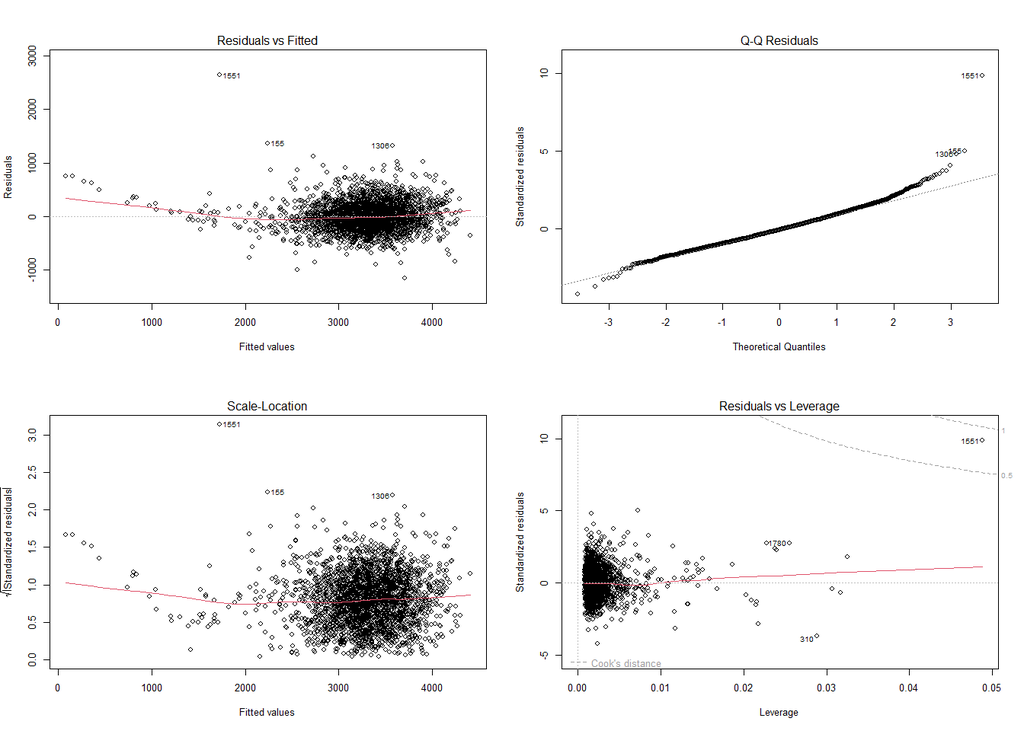

```r
par(mfrow=c(2,2))
plot(mod5)
```

which depicts the residuals of `mod5` as a function of the fitted values. Therefore, we now try to add the corresponding quadratic terms and see if the new model provides a better fit:

```r
mod6 <- update(mod5,~.+I(Gestation.weeks^2)+I(Length^2)+I(Cranium^2))
summary(mod6)
```

```
##
## Call:
## lm(formula = Weight ~ Pregnancies.number + Gestation.weeks +
##     Length + Cranium + Sex + I(Gestation.weeks^2) + I(Length^2) +
##     I(Cranium^2), data = data)
##
## Residuals:
##      Min       1Q   Median       3Q      Max
## -1187.03  -182.50   -12.03   162.60  1469.62
##
## Coefficients:
##                        Estimate Std. Error t value Pr(>|t|)
## (Intercept)          -1.217e+03  1.160e+03  -1.049   0.2945
## Pregnancies.number    1.441e+01  4.246e+00   3.394   0.0007 ***
## Gestation.weeks       3.754e+02  6.738e+01   5.572 2.79e-08 ***
## Length               -2.925e+01  4.436e+00  -6.592 5.28e-11 ***
## Cranium              -4.979e+00  9.804e+00  -0.508   0.6116
## SexM                  7.232e+01  1.100e+01   6.577 5.83e-11 ***
## I(Gestation.weeks^2) -4.374e+00  8.834e-01  -4.951 7.86e-07 ***
## I(Length^2)           4.075e-02  4.544e-03   8.967  < 2e-16 ***
## I(Cranium^2)          2.276e-02  1.445e-02   1.575   0.1154
## ---
## Signif. codes:  0 '***' 0.001 '**' 0.01 '*' 0.05 '.' 0.1 ' ' 1
##
## Residual standard error: 268.4 on 2491 degrees of freedom
## Multiple R-squared:  0.7395, Adjusted R-squared:  0.7387
## F-statistic: 883.9 on 8 and 2491 DF,  p-value: < 2.2e-16
```

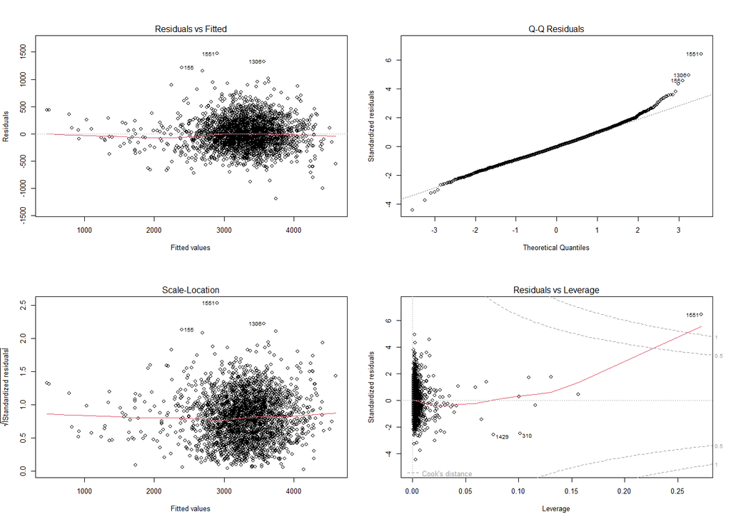

```r
par(mfrow=c(2,2))
plot(mod6)
```

The addition of the terms quadratic in the predictors lead to a decrease in the values of the residuals, which now exhibit a more “horizontal” shape, if compared to those of `mod5`. However, unlike before, the `Cranium` variable seems not to be statically significant anymore. Before removing its main effect, let us first drop its non-linear effect and see what happens:

```r
mod7 <- update(mod6,~.-I(Cranium^2))
summary(mod7)
```

```
##
## Call:
## lm(formula = Weight ~ Pregnancies.number + Gestation.weeks +
##     Length + Cranium + Sex + I(Gestation.weeks^2) + I(Length^2),
##     data = data)
##
## Residuals:
##      Min       1Q   Median       3Q      Max
## -1191.07  -182.28   -13.74   163.34  1403.53
##
## Coefficients:
##                        Estimate Std. Error t value Pr(>|t|)
## (Intercept)          -2.360e+03  9.053e+02  -2.607  0.00919 **
## Pregnancies.number    1.448e+01  4.247e+00   3.410  0.00066 ***
## Gestation.weeks       3.365e+02  6.270e+01   5.367 8.74e-08 ***
## Length               -3.215e+01  4.037e+00  -7.963 2.53e-15 ***
## Cranium               1.045e+01  4.192e-01  24.922  < 2e-16 ***
## SexM                  7.261e+01  1.100e+01   6.602 4.93e-11 ***
## I(Gestation.weeks^2) -3.873e+00  8.245e-01  -4.698 2.77e-06 ***
## I(Length^2)           4.370e-02  4.140e-03  10.556  < 2e-16 ***
## ---
## Signif. codes:  0 '***' 0.001 '**' 0.01 '*' 0.05 '.' 0.1 ' ' 1
##
## Residual standard error: 268.5 on 2492 degrees of freedom
## Multiple R-squared:  0.7392, Adjusted R-squared:  0.7385
## F-statistic:  1009 on 7 and 2492 DF,  p-value: < 2.2e-16
```

The `Cranium` variable has again become statistically significant, therefore we keep it. Furthermore, the adjusted $R^2$ has only very slightly decreased, thus we are led to prefer `mod7` to `mod6`. However, to decide the best model, let us look at the values of the BIC and the AIC of all the models we built:

```r
BIC(mod1,mod2,mod3,mod4,mod5,mod6,mod7)
```

```
##      df      BIC
## mod1 12 35241.97
## mod2 11 35234.64
## mod3  9 35228.24
## mod4  8 35221.75
## mod5  7 35220.10
## mod6 10 35126.48
## mod7  9 35121.14
```

```r
AIC(mod1,mod2,mod3,mod4,mod5,mod6,mod7)
```

```
##      df      AIC
## mod1 12 35172.09
## mod2 11 35170.57
## mod3  9 35175.83
## mod4  8 35175.16
## mod5  7 35179.33
## mod6 10 35068.24
## mod7  9 35068.73
```

Before going on, let us also assess the presence of **multicollinearity** by computing the variance inflation factors (VIFs) of `mod7`:

```r
vif(mod7, type="predictor")
```

```
##                        GVIF Df GVIF^(1/(2*Df))       Interacts With
## Pregnancies.number 1.025434  1        1.012637                 --
## Gestation.weeks    3.100126  2        1.326920 I(Gestation.weeks^2)
## Length             3.746905  2        1.391292          I(Length^2)
## Cranium            1.643288  1        1.281908                 --
## Sex                1.048541  1        1.023983                 --
##                                                        Other Predictors
## Pregnancies.number                Gestation.weeks, Length, Cranium, Sex
## Gestation.weeks                Pregnancies.number, Length, Cranium, Sex
## Length                Pregnancies.number, Gestation.weeks, Cranium, Sex
## Cranium                Pregnancies.number, Gestation.weeks, Length, Sex
## Sex                Pregnancies.number, Gestation.weeks, Length, Cranium
```

Since all the VIFs are less than 5, no significant levels of multicollinearity are found.

Let us analyse the residuals of `mod7`:

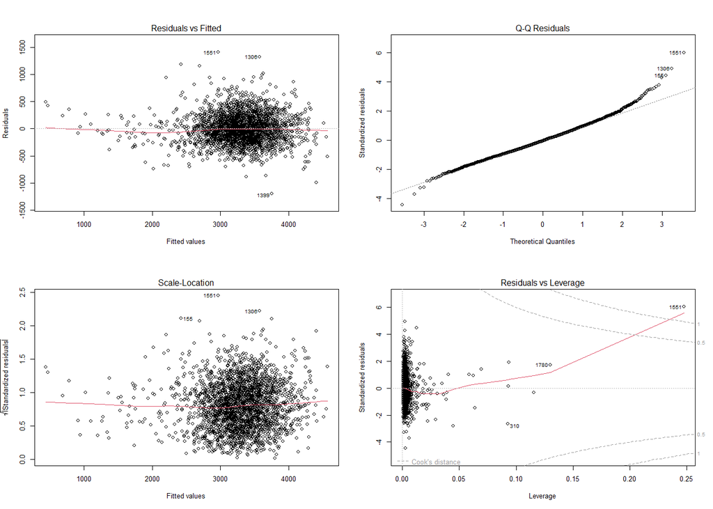

```r
par(mfrow=c(2,2))
plot(mod7)
```

where the red lines are smooth fits, intended to make it easier to identify a trend. Let us check if their mean is compatible with zero:

```r
mean(residuals(mod7));sd(residuals(mod7))
```

```
## [1] 1.461354e-14
```

```
## [1] 268.1125
```

Therefore, we can say that in our case the residuals have zero mean.  
We now test the hypothesis of **homoscedasticity** by means of the **Breusch-Pagan test**:

```r
bptest(mod7)
```

```
##
##  studentized Breusch-Pagan test
##
## data:  mod7
## BP = 97.553, df = 7, p-value < 2.2e-16
```

The test leads us to reject the null hypothesis, thus we conclude that the residuals are heteroscedastic, meaning that they do not have a constant variance.

Let us now perform the **Durbin-Watson test** to verify the hypothesis of **independence** of the residuals:

```r
dwtest(mod7)
```

```
##
##  Durbin-Watson test
##
## data:  mod7
## DW = 1.9494, p-value = 0.1028
## alternative hypothesis: true autocorrelation is greater than 0
```

In this case, the p-value is greater than the significance level of 5%, therefore we do not reject the null hypothesis that the errors are uncorrelated. This is good, since the standard errors of the estimated regression coefficients, which are used to compute the t-statistic, are based on the assumption of uncorrelated error terms.

Finally, let us study the presence of **outliers** and/or **high leverage points**: the former are points for which $y_i$ is far from the value predicted by the model, while observations with high leverage have an unusual value for $x_i$.  
To quantify whether a point is problematic or not, we utilise the plot at bottom right of the previous figure. In particular, we see that the only value having a Cook’s distance bigger than the critical value of 1 is the observation n. 1551:

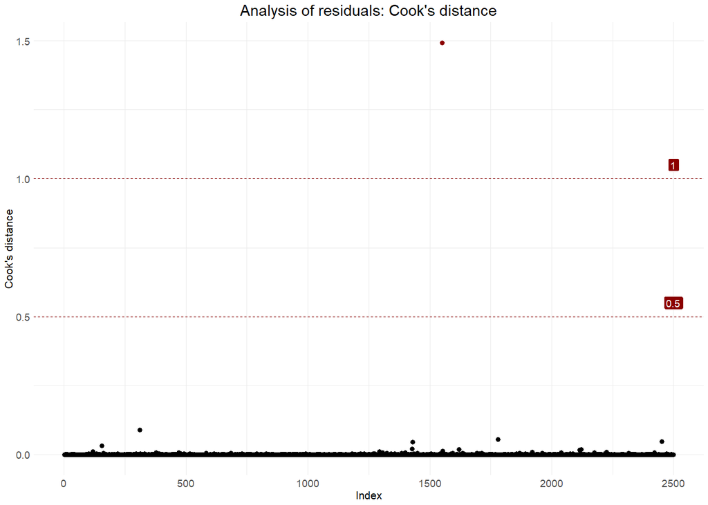

```r
cook <- cooks.distance(mod7)
ggplot()+
    geom_point(aes(x=1:length(cook),
                   y=cook,
                   colour = cook>1),
               size = 3)+
    geom_hline(aes(yintercept=c(0.5,1)),
               linetype=2,
               colour = "darkred")+
    geom_label(aes(x=2500,y=c(0.55,1.05),label=c(0.5,1)),
              size=5,
              fill="darkred",
              colour = "white")+
    scale_colour_manual(values = setNames(c("darkred","black"),c(T,F)))+
    labs(title = "Analysis of residuals: Cook's distance",
         x = "Index",
         y = "Cook's distance")+
    theme_minimal()+
    theme(plot.title = element_text(size = 22, hjust = 0.5),
          axis.text.x = element_text(size = 14),
          axis.text.y = element_text(size = 14),
          axis.title = element_text(size = 16),
          legend.position = "none")
```

Therefore, having a very large Cook’s distance, let us try to remove this value and perform again the multiple linear regression:

```r
index <- match(max(cook),cook)
new_data <- data[-index,]
mod8 <- lm(Weight ~ Pregnancies.number + Gestation.weeks +
               Length + Cranium + Sex + I(Gestation.weeks^2) + I(Length^2),
           data = new_data)
summary(mod8)
```

```
##
## Call:
## lm(formula = Weight ~ Pregnancies.number + Gestation.weeks +
##     Length + Cranium + Sex + I(Gestation.weeks^2) + I(Length^2),
##     data = new_data)
##
## Residuals:
##      Min       1Q   Median       3Q      Max
## -1187.72  -180.63   -13.61   164.12  1320.11
##
## Coefficients:
##                        Estimate Std. Error t value Pr(>|t|)
## (Intercept)          -2.811e+03  9.019e+02  -3.117 0.001848 **
## Pregnancies.number    1.440e+01  4.217e+00   3.414 0.000651 ***
## Gestation.weeks       2.004e+02  6.617e+01   3.028 0.002489 **
## Length               -1.928e+01  4.535e+00  -4.252 2.20e-05 ***
## Cranium               1.009e+01  4.202e-01  24.023  < 2e-16 ***
## SexM                  7.340e+01  1.092e+01   6.721 2.22e-11 ***
## I(Gestation.weeks^2) -2.135e+00  8.673e-01  -2.462 0.013890 *
## I(Length^2)           3.093e-02  4.618e-03   6.697 2.62e-11 ***
## ---
## Signif. codes:  0 '***' 0.001 '**' 0.01 '*' 0.05 '.' 0.1 ' ' 1
##
## Residual standard error: 266.6 on 2491 degrees of freedom
## Multiple R-squared:  0.7426, Adjusted R-squared:  0.7419
## F-statistic:  1027 on 7 and 2491 DF,  p-value: < 2.2e-16
```

The removal of the observation causes an increase in the adjusted $R^2$, but also a substantial increase in the p-value of the coefficient associated to `I(Gestation.weeks^2)`, even though still statistically significant. Let us try to remove it:

```r
mod9 <- update(mod8,~.-I(Gestation.weeks^2))
summary(mod9)
```

```
##
## Call:
## lm(formula = Weight ~ Pregnancies.number + Gestation.weeks +
##     Length + Cranium + Sex + I(Length^2), data = new_data)
##
## Residuals:
##      Min       1Q   Median       3Q      Max
## -1176.79  -178.89   -12.52   164.19  1327.44
##
## Coefficients:
##                      Estimate Std. Error t value Pr(>|t|)
## (Intercept)        -1.607e+03  7.586e+02  -2.119 0.034207 *
## Pregnancies.number  1.420e+01  4.220e+00   3.364 0.000781 ***
## Gestation.weeks     3.773e+01  3.890e+00   9.700  < 2e-16 ***
## Length             -1.172e+01  3.342e+00  -3.508 0.000459 ***
## Cranium             1.015e+01  4.201e-01  24.157  < 2e-16 ***
## SexM                7.222e+01  1.092e+01   6.614 4.57e-11 ***
## I(Length^2)         2.330e-02  3.430e-03   6.795 1.35e-11 ***
## ---
## Signif. codes:  0 '***' 0.001 '**' 0.01 '*' 0.05 '.' 0.1 ' ' 1
##
## Residual standard error: 266.8 on 2492 degrees of freedom
## Multiple R-squared:  0.742,  Adjusted R-squared:  0.7413
## F-statistic:  1194 on 6 and 2492 DF,  p-value: < 2.2e-16
```

```r
BIC(mod7,mod8,mod9)
```

```
##      df      BIC
## mod7  9 35121.14
## mod8  9 35071.44
## mod9  8 35069.69
```

Based on the value of BIC, we are led to choose `mod9` as the best multiple linear regression model. Let us consider its residuals:

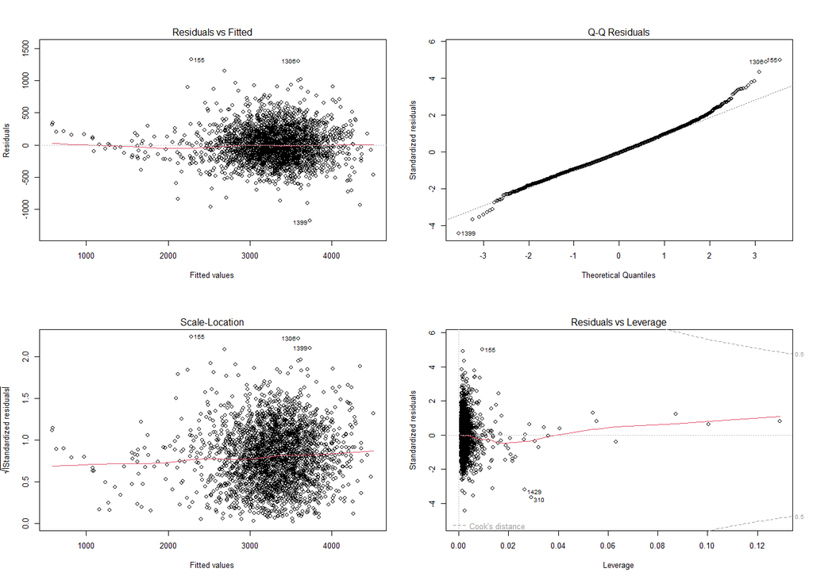

```r
par(mfrow=c(2,2))
plot(mod9)
```

As before, we do not reject the hypothesis of uncorrelation of the residuals, as can be seen from the Durbin-Watson test:

```r
dwtest(mod9)
```

```
##
##  Durbin-Watson test
##
## data:  mod9
## DW = 1.9498, p-value = 0.1046
## alternative hypothesis: true autocorrelation is greater than 0
```

Let us now perform the Breusch-Pagan test:

```r
bptest(mod7);bptest(mod9)
```

```
##
##  studentized Breusch-Pagan test
##
## data:  mod7
## BP = 97.553, df = 7, p-value < 2.2e-16
```

```
##
##  studentized Breusch-Pagan test
##
## data:  mod9
## BP = 15.47, df = 6, p-value = 0.0169
```

The p-value of the Breush-Pagan test is now significantly higher than before, so that we do not reject the hypothesis of homoscedasticity, if we set the significance level to 0.01. Therefore, we can conclude that `mod9` can be used to make a reliable prediction of a newborn’s weight.

Let us try to simplify the model in order to visualize the data, nevertheless keeping the essential ingredients. To this aim, we divide the data according to the newborn’s sex. Then, we choose other two variables between the predictors of `mod9`, which are `Gestation.weeks`, `Pregnancies.number`, `Length` and `Cranium`. For example, let us consider the couple of variables given by `Gestation.weeks` and `Length`. Therefore, we obtain the following 3-dimensional scatterplot:

```r
colors <- c("pink","lightblue")
colors <- colors[as.numeric(data$Sex)]
s3d <- scatterplot3d(data$Weight~data$Gestation.weeks+data$Length,
                     color = colors,
                     pch = 16,
                     angle = 50,
                     main = "3D Scatter plot",
                     xlab = "Gestation weeks",
                     ylab = "Length (mm)",
                     zlab = "Baby's weight (g)",
                     grid = T,
                     box = F)
legend("bottom", legend = levels(data$Sex),
      col =  c("pink", "lightblue"),
      pch = 16,
      inset = -0.25,
      xpd = TRUE,
      horiz = TRUE)
F_data <- filter(data, Sex=="F")
M_data <- filter(data, Sex=="M")
my.lm_F <- lm(Weight ~ Gestation.weeks + Length, data = F_data)
my.lm_M <- lm(Weight ~ Gestation.weeks + Length, data = M_data)
summary(my.lm_F)
```

```
##
## Call:
## lm(formula = Weight ~ Gestation.weeks + Length, data = F_data)
##
## Residuals:
##     Min      1Q  Median      3Q     Max
## -1086.7  -197.6   -29.4   184.0  3511.1
##
## Coefficients:
##                   Estimate Std. Error t value Pr(>|t|)
## (Intercept)     -5018.9396   184.4583 -27.209  < 2e-16 ***
## Gestation.weeks    47.1209     5.7142   8.246 4.08e-16 ***
## Length             12.9755     0.4129  31.426  < 2e-16 ***
## ---
## Signif. codes:  0 '***' 0.001 '**' 0.01 '*' 0.05 '.' 0.1 ' ' 1
##
## Residual standard error: 314.4 on 1253 degrees of freedom
## Multiple R-squared:  0.6436, Adjusted R-squared:  0.6431
## F-statistic:  1132 on 2 and 1253 DF,  p-value: < 2.2e-16
```

```r
summary(my.lm_M)
```

```
##
## Call:
## lm(formula = Weight ~ Gestation.weeks + Length, data = M_data)
##
## Residuals:
##      Min       1Q   Median       3Q      Max
## -1161.38  -189.49   -19.46   181.77  1626.97
##
## Coefficients:
##                   Estimate Std. Error t value Pr(>|t|)
## (Intercept)     -5420.3430   210.6163 -25.736  < 2e-16 ***
## Gestation.weeks    41.7670     6.1989   6.738 2.46e-11 ***
## Length             14.3897     0.4391  32.769  < 2e-16 ***
## ---
## Signif. codes:  0 '***' 0.001 '**' 0.01 '*' 0.05 '.' 0.1 ' ' 1
##
## Residual standard error: 300.4 on 1241 degrees of freedom
## Multiple R-squared:  0.6305, Adjusted R-squared:  0.6299
## F-statistic:  1059 on 2 and 1241 DF,  p-value: < 2.2e-16
```

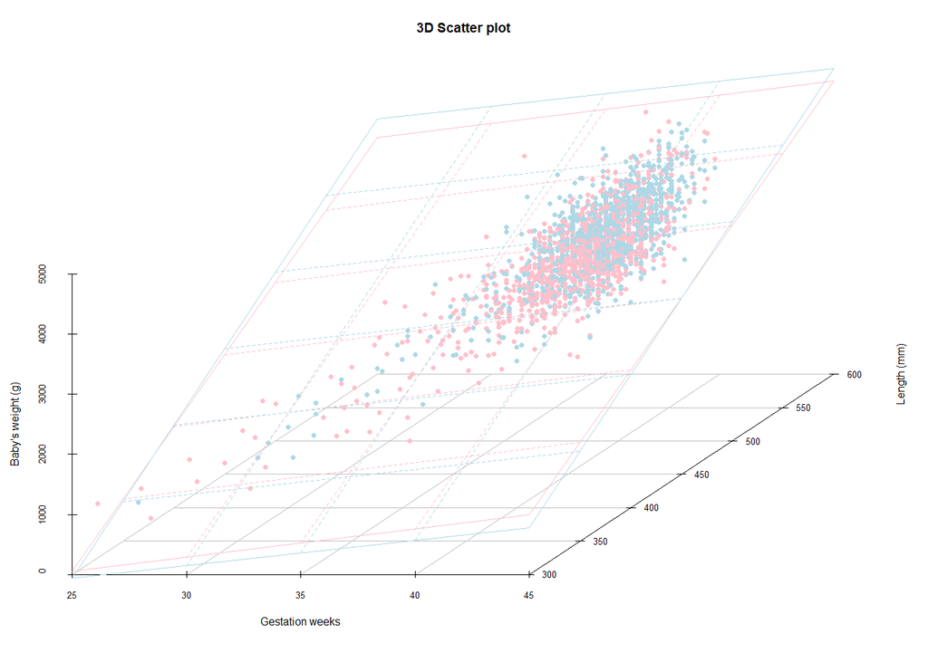

```r
s3d$plane3d(my.lm_F, lty.box = "solid", col = "pink", lwd = 1.5)
s3d$plane3d(my.lm_M, lty.box = "solid", col = "lightblue", lwd = 1.5)
```

From the two regression planes we see that, if we keep fixed the number of weeks of gestation, the weight will increase more for a boy than for a girl.

In conclusion, let us make a prediction for a newborn’s weight. For example, let us consider a mother that:

- has already gone through 2 pregnancies;
- will deliver her baby during the 39th week.

Let us also suppose that we do not have information about the length and the diameter of the cranium. In this case, we can use their mean values to give an estimate of these parameters. To be more precise, we consider the mean values related to the girls, since we saw before that the length and the diameter are significantly influenced by the sex of the newborn. Having said that, we obtain that the predicted value of her weight will be:

```r
predict(mod9,
        newdata = data.frame(Sex="F",Gestation.weeks=39,Pregnancies.number=2,
                             Length=mean(data$Length[data$Sex=="F"]),
                             Cranium=mean(data$Cranium[data$Sex=="F"])),
        interval = "predict")
```

```
##        fit      lwr      upr
## 1 3166.765 2643.193 3690.337
```

```r
3166.765-2643.193;3690.337-3166.765
```

```
## [1] 523.572
```

```
## [1] 523.572
```

where `lwr` and `upr` represent the extreme values of the corresponding 95% prediction interval. Therefore, we predict the baby’s weight to be:
$$\begin{equation}
m=3167\pm524\,\text{g}
\end{equation}$$
In other words, there is a 95% chance that the newborn’s weight will be between $2643\,\text{g}$ and $3690\,\text{g}$.